{% raw %}

{% endraw %}

In this tutorial, we will see how we can use the fastai library to fine-tune a pretrained transformer model from the [transformers library](https://github.com/huggingface/transformers) by HuggingFace. We will use the mid-level API to gather the data. Even if this tutorial is self contained, it might help to check the [imagenette tutorial](http://dev.fast.ai/tutorial.imagenette) to have a second look on the mid-level API (with a gentle introduction using the higher level APIs) in computer vision.

## Importing a transformers pretrained model

First things first, we will need to install the transformers library. If you haven't done it yet, just uncomment the following cell.

{% raw %}

{% endraw %}

Then let's import what will need: we will fine-tune the GPT2 pretrained model and fine-tune on wikitext-2 here. For this, we need the `GPT2LMHeadModel` (since we want a language model) and the `GPT2Tokenizer` to prepare the data.

{% raw %}

```python
from transformers import GPT2LMHeadModel, GPT2TokenizerFast
```

[output not shown]

{% endraw %}

We can use several verions of this GPT2 model, look at the [transformers documentation](https://huggingface.co/transformers/pretrained_models.html) for more details. Here we will use the basic version (that laready takes a lot of space in memory!) You can change the model used by changing the content of `pretrained_weights` (if it's not a GPT2 model, you'll need to change the classes used for the model and the tokenizer of course).

{% raw %}

```python
pretrained_weights = 'gpt2'
tokenizer = GPT2TokenizerFast.from_pretrained(pretrained_weights)
model = GPT2LMHeadModel.from_pretrained(pretrained_weights)
```

{% endraw %}

Before we move on to the fine-tuning part, let's have a look at this `tokenizer` and this `model`. The tokenizers in HuggingFace usually do the tokenization and the numericalization in one step (we ignore the padding warning for now):

{% raw %}

```python
ids = tokenizer.encode('This is an example of text, and')
ids
```

```
Using pad_token, but it is not set yet.
```

```
[1212, 318, 281, 1672, 286, 2420, 11, 290]
```

{% endraw %}

Like fastai `Transform`s, the tokenizer has a `decode` method to give you back a text from ids:

{% raw %}

```python
tokenizer.decode(ids)
```

```
'This is an example of text, and'
```

{% endraw %}

The model can be used to generate predictions (it is pretrained). It has a `generate` method that expects a batch of prompt, so we feed it our ids and add one batch dimension (there is a padding warning we can ignore as well):

{% raw %}

```python
import torch
t = torch.LongTensor(ids)[None]
preds = model.generate(t)
```

[output not shown]

{% endraw %}

The predictions, by default, are of length 20:

{% raw %}

```python
preds.shape,preds[0]
```

```
(torch.Size([1, 20]),
 tensor([1212,  318,  281, 1672,  286, 2420,   11,  290,  340,  338,  407,  257,
          922,  530,   13,  198,  198,  464,  717, 1517]))
```

{% endraw %}

We can use the decode method (that prefers a numpy array to a tensor):

{% raw %}

```python
tokenizer.decode(preds[0].numpy())
```

```
"This is an example of text, and it's not a good one.\n\nThe first thing"
```

{% endraw %}

## Bridging the gap with fastai

Now let's see how we can use fastai to fine-tune this model on wikitext-2, using all the training utilies (learning rate finder, 1cycle policy etc...). First, we import all the text utilities:

{% raw %}

```python
from fastai2.text.all import *
```

{% endraw %}

### Preparing the data

Then we download the dataset (if not present), it comes as two csv files:

{% raw %}

```python
path = untar_data(URLs.WIKITEXT_TINY)
path.ls()
```

```
(#2) [Path('/home/sgugger/.fastai/data/wikitext-2/train.csv'),Path('/home/sgugger/.fastai/data/wikitext-2/test.csv')]
```

{% endraw %}

Let's have a look at what those csv files look like:

{% raw %}

```python
df_train = pd.read_csv(path/'train.csv', header=None)
df_valid = pd.read_csv(path/'test.csv', header=None)
df_train.head()
```

|  | 0 |
| --- | --- |
| 0 | \n = 2013 – 14 York City F.C. season = \n \n The 2013 – 14 season was the <unk> season of competitive association football and 77th season in the Football League played by York City Football Club , a … |
| 1 | \n = Big Boy ( song ) = \n \n " Big Boy " <unk> " I 'm A Big Boy Now " was the first single ever recorded by the Jackson 5 , which was released by Steeltown Records in January 1968 . The group played … |
| 2 | \n = The Remix ( Lady Gaga album ) = \n \n The Remix is a remix album by American recording artist Lady Gaga . Released in Japan on March 3 , 2010 , it contains remixes of the songs from her first stu… |
| 3 | \n = New Year 's Eve ( Up All Night ) = \n \n " New Year 's Eve " is the twelfth episode of the first season of the American comedy television series Up All Night . The episode originally aired on NBC… |
| 4 | \n = Geopyxis carbonaria = \n \n Geopyxis carbonaria is a species of fungus in the genus Geopyxis , family <unk> . First described to science in 1805 , and given its current name in 1889 , the species… |

{% endraw %}

We gather all texts in one numpy array (since it will be easier to use this way with fastai):

{% raw %}

```python
all_texts = np.concatenate([df_train[0].values, df_valid[0].values])
```

{% endraw %}

To process this data to train a model, we need to build a `Transform` that will be applied lazily. In this case we might could do the pre-processing once and for all and only use the transform for decoding (we will see how just after), but the fast tokenizer from HuggingFace is, as its name indicates, fast, so it doesn't really impact performance to do it this way.

In a fastai `Transform` you can define:

- an `encodes` method that is applied when you call the transform (a bit like the `forward` method in a `nn.Module`)
- a `decodes` method that is applied when you call the `decode` method of the transform, if you need to decode anything for showing purposes (like converting ids to a text here)
- a `setups` method that sets some inner state of the `Transform` (not needed here so we skip it)

{% raw %}

```python
class TransformersTokenizer(Transform):
    def __init__(self, tokenizer): self.tokenizer = tokenizer
    def encodes(self, x):
        toks = self.tokenizer.tokenize(x)
        return tensor(self.tokenizer.convert_tokens_to_ids(toks))
    def decodes(self, x): return TitledStr(self.tokenizer.decode(x.cpu().numpy()))
```

{% endraw %}

Two comments on the code above:

- in `encodes` we don't use the `tokenizer.encode` method since it does some additional preprocessing for the model after tokenizing and numericalizing (the aprt throwing a warning before). Here we don't need any post-processing so it's fine to skip it.
- in `decodes` we return a `TitledStr` object and not jsut a plain string. That's a fastai class that adds a `show` method to the string, which will allow us to use all the fastai show methods.

You can then group your data with this `Transform` using a `TfmdLists`. It has an s in its name because it contains the training and validation set. We indicate the indices of the training set and the validation set with `splits` (here all the first indices until `len(df_train)` and then all the remaining indices):

{% raw %}

```python
splits = [list(range_of(df_train)), list(range(len(df_train), len(all_texts)))]
tls = TfmdLists(all_texts, TransformersTokenizer(tokenizer), splits=splits, dl_type=LMDataLoader)
```

{% endraw %}

We specify `dl_type=LMDataLoader` for when we will convert this `TfmdLists` to `DataLoaders`: we will use an `LMDataLoader` since we have a language modeling problem, not the usual fastai `TfmdDL`.

In a `TfmdLists` you can access to the elements of the training or validation set quite easily:

{% raw %}

```python
tls.train[0],tls.valid[0]
```

```
(tensor([220, 198, 796,  ..., 198, 220, 198]),
 tensor([220, 198, 796,  ..., 198, 220, 198]))
```

{% endraw %}

They both look the same but that just begins they begin and end the same way, we can see the shape are differents:

{% raw %}

```python
tls.tfms(tls.train.items[0]).shape, tls.tfms(tls.valid.items[0]).shape
```

```
(torch.Size([4576]), torch.Size([1485]))
```

{% endraw %}

And we can have a look at both decodes using `show_at`:

{% raw %}

```python
show_at(tls.train, 0)
```

```
 = 2013 – 14 York City F.C. season =

 The 2013 – 14 season was the <unk> season of competitive association football and 77th season in the Football League played by York City Football Club, a professional football club based in York, North Yorkshire, England. Their 17th @-@ place finish in 2012 – 13 meant it was their second consecutiv…
 Nigel Worthington, starting his first full season as York manager, made eight permanent summer signings. By the turn of the year York were only above the relegation zone on goal difference, before a 17 @-@ match unbeaten run saw the team finish in seventh @-@ place in the 24 @-@ team 2013 – 14 Foot…
 35 players made at least one appearance in nationally organised first @-@ team competition, and there were 12 different <unk>. Defender Ben Davies missed only five of the fifty @-@ two competitive matches played over the season. Wes Fletcher finished as leading scorer with 13 goals, of which 10 cam…

 = = Background and pre @-@ season = =

 The 2012 – 13 season was York City's first season back in the Football League, having won the Conference Premier play @-@ offs in 2011 – 12 after <unk> years in the Football Conference. Manager Gary Mills was sacked in March 2013 following an 11 @-@ match run without a victory, and was replaced by …
 Following the previous season's conclusion Lee <unk>, Jon <unk>, Chris <unk>, Ben Everson, Scott Kerr, David <unk>, Patrick <unk>, Michael Potts, Jamie Reed and Jason Walker were released by York, while <unk> Blair departed for Fleetwood Town. David McGurk, <unk> Oyebanjo, Danny Parslow, Tom Platt …
 York retained the previous season's home and away kits. The home kit comprised red shirts with white sleeves, light blue shorts and white socks. The away kit included light blue shirts with white sleeves, white shorts and light blue socks. <unk> Health continued as shirt sponsors for the second suc…

 = = Review = =


 = = = August = = =

 York began the season with a 1 – 0 home win over the previous season's play @-@ off finalists, Northampton Town, with <unk> Jarvis scoring the winning goal in the 90th @-@ minute. However, defeat came in York's match against Championship side Burnley in the first round of the League Cup, going down…

 = = = September = = =

 York suffered their first home league defeat of the season after AFC Wimbledon won 2 – 0, with Michael Smith scoring in each half. Former Ipswich Town midfielder Josh Carson, who had a spell on loan with York the previous season, signed a contract until the end of 2013 – 14 and Sheffield United mid…

 = = = October = = =

 Defender Luke O 'Neill was signed from Burnley on a 28 @-@ day emergency loan. He made his debut in York's 3 – 0 win away at Torquay, which was the team's first successive win of the season. York were knocked out of the Football League Trophy in the second round after being beaten 3 – 0 at home by …

 = = = November = = =

 Bowman scored his first goals for York away to Cheltenham Town, as York twice fought back from behind to draw 2 – 2. York drew 3 – 3 away to Bristol Rovers to earn a first round replay in the FA Cup, taking the lead through Jarvis before Eliot Richards equalised for the home team. Carson scored a 3…
 Defender Keith Lowe, of Cheltenham, and goalkeeper Nick Pope, of Charlton Athletic, were signed on loan until January 2014. They both played in York's first league defeat in four weeks, 2 – 1 away, to Southend United. <unk> <unk> gave Southend the lead early into the match and Bowman equalised for …

 = = = December = = =

 Cresswell retired from playing as a result of an eye complaint and a knee injury. York drew 1 – 1 away to Burton Albion, with an own goal scored by Shane <unk> @-@ <unk> giving York the lead in the 64th @-@ minute before the home team equalised eight minutes later through Billy <unk>. Atkinson was …

 = = = January = = =

 Jarvis scored the only goal in York's first win since October 2013, a 1 – 0 home victory over Morecambe on New Year's Day. McCarey was recalled by Wolverhampton Wanderers due to an injury to one of their <unk>, while O 'Neill was recalled by Burnley to take part in their FA Cup match. York achieved…
 York achieved three successive wins for the first time in 2013 – 14 after beating Northampton 2 – 0 away, with Bowman and Fletcher scoring in three @-@ second half minutes. Defender John McCombe was signed on a two @-@ and @-@ a @-@ half @-@ year contract following his release from Mansfield, befor…
```

[output cut: 55 more lines]

```

 = = = Loan in = = =


 = = = Loan out = = =


 = = Appearances and goals = =

 Source :
 Numbers in parentheses denote appearances as substitute.
 Players with names struck through and marked left the club during the playing season.
 Players with names in italics and marked * were on loan from another club for the whole of their season with York.
 Players listed with no appearances have been in the <unk> squad but only as unused <unk>.
 Key to positions : <unk> – <unk> ; <unk> – Defender ; <unk> – <unk> ; <unk> – Forward
```

{% endraw %} {% raw %}

```python
show_at(tls.valid, 0)
```

```
 = Tropical Storm <unk> ( 2008 ) =

 Tropical Storm <unk> was the tenth tropical storm of the 2008 Atlantic hurricane season. <unk> developed out of a strong tropical wave which moved off the African coast on August 31. The wave quickly became organized and was declared Tropical Depression Ten while located 170 mi ( 270 km ) to the so…

 = = Meteorological history = =

 Tropical Storm <unk> formed as a tropical wave that emerged off the west coast of Africa near the end of August 2008. It tracked south of Cape Verde and slowly developed, and on September 2 the disturbance became Tropical Depression Ten while located south @-@ southeast of the Cape Verde islands. A…
 <unk> continued to intensify throughout the afternoon as the storm became more symmetrical. However, due to the location of the storm, there was a lack of accurate wind speed readings, and the National Hurricane Center was uncertain of its actual intensity. Despite the lack of wind shear around the…
 <unk> reached its peak intensity of 65 mph ( 100 km / h ) around 8 a.m. ( <unk> ) as it continued to become more organized. However, there were indications that it had already begun to weaken. <unk> towards the north was becoming restricted and arc clouds began emanating from the storm, a sign that…
 Despite continuing effects from the strong wind shear, a large, deep burst of convection formed in the northern <unk> of <unk>. The center was found to have shifted towards the new convection leading to an increase in intensity. The forecast showed a slight decrease in wind shear as <unk> continued…
 The weakening trend continued through the afternoon as the storm was being affected by strong <unk> shear. <unk> became almost fully devoid of any convection by mid @-@ afternoon and the storm weakened to 40 mph ( 65 km / h ), barely holding on to tropical storm status. <unk> regained a small amoun…
 However, the remnant low associated with <unk> began to show signs of redevelopment during the afternoon on September 7. <unk> around the system increased significantly and the low was no longer exposed. On September 8, wind shear took over the system again. <unk> around the remnant low was torn aw…

 = = Impact = =

 As <unk> passed to the south of the Cape Verde islands on September 2, outer rain bands produced minor rainfall, totaling around 0 @.@ 55 inches ( 14 mm ). There were no reports of damage or flooding from the rain and overall effects were minor.
 Several days after the low dissipated, the remnant moisture from <unk> brought showers and thunderstorms to St. Croix where up to 1 in ( 25 @.@ 4 mm ) of rain fell. The heavy rains led to minor street flooding and some urban flooding. No known damage was caused by the flood.
```

{% endraw %}

The fastai library expects the data to be assembled in a `DataLoaders` object (something that has a training and validation dataloader). We can get one by using the `dataloaders` method. We just have to specify a batch size and a sequence length. Since the GPT2 model was trained with sequences of size 1024, we use this sequence length (it's a stateless model, so it will change the perplexity if we use less):

{% raw %}

```python
bs,sl = 8,1024
dls = tls.dataloaders(bs=bs, seq_len=sl)
```

{% endraw %}

Note that you may have to reduce the batch size depending on your GPU RAM.

In fastai, as soo as we have a `DataLoaders`, we can use `show_batch` to have a look at the data (here texts for inputs, and the same text shifted by one token to the right for validation):

{% raw %}

```python
dls.show_batch(max_n=5)
```

|  | text | text_ |
| --- | --- | --- |
| 0 | \n = History of artificial intelligence = \n \n The history of artificial intelligence ( AI ) began in antiquity, with myths, stories and rumors of artificial beings endowed with intelligence or consc… | \n = History of artificial intelligence = \n \n The history of artificial intelligence ( AI ) began in antiquity, with myths, stories and rumors of artificial beings endowed with intelligence or consc… |
| 1 | och from <unk> in Orkney, which has a Pictish @-@ style looped pin. It is about two inches in diameter, with traces of <unk>, and probably housed a piece of amber surrounded by <unk> ribbons. After th… | from <unk> in Orkney, which has a Pictish @-@ style looped pin. It is about two inches in diameter, with traces of <unk>, and probably housed a piece of amber surrounded by <unk> ribbons. After the co… |
| 2 | @ match unbeaten run saw the team finish in seventh @-@ place in the 24 @-@ team 2013 – 14 Football League Two. This meant York qualified for the play @-@ offs, and they were eliminated in the semi @-… | match unbeaten run saw the team finish in seventh @-@ place in the 24 @-@ team 2013 – 14 Football League Two. This meant York qualified for the play @-@ offs, and they were eliminated in the semi @-@ … |
| 3 | more likely to be found in areas that were heavily burned, compared to locations with light to moderate burning where the trees remained viable, or in <unk> areas. <unk> was much denser in spruce fore… | likely to be found in areas that were heavily burned, compared to locations with light to moderate burning where the trees remained viable, or in <unk> areas. <unk> was much denser in spruce forests —… |
| 4 | = = = \n \n The degree to which Tennyson identifies with Ulysses has provided one of the great debates among scholars of the poem. Critics who find that Tennyson identifies with the speaker read Ulyss… | = = \n \n The degree to which Tennyson identifies with Ulysses has provided one of the great debates among scholars of the poem. Critics who find that Tennyson identifies with the speaker read Ulysses… |

{% endraw %}

Another way to gather the data is to preprocess the texts once and for all and only use the transform to decode the tensors to texts:

{% raw %}

```python
def tokenize(text):
    toks = tokenizer.tokenize(text)
    return tensor(tokenizer.convert_tokens_to_ids(toks))

tokenized = [tokenize(t) for t in progress_bar(all_texts)]
```

100.00% [662/662 00:05<00:00]

{% endraw %}

Now we change the previous `Tokenizer` like this:

{% raw %}

```python
class TransformersTokenizer(Transform):
    def __init__(self, tokenizer): self.tokenizer = tokenizer
    def encodes(self, x):
        return x if isinstance(x, Tensor) else tokenize(x)

    def decodes(self, x): return TitledStr(self.tokenizer.decode(x.cpu().numpy()))
```

{% endraw %}

In the `encodes` method, we still account for the case where we get something that's not already tokenized, just in case we were to build a dataset with new texts using this transform.

{% raw %}

```python
tls = TfmdLists(tokenized, TransformersTokenizer(tokenizer), splits=splits, dl_type=LMDataLoader)
dls = tls.dataloaders(bs=bs, seq_len=sl)
```

{% endraw %}

And we can check it still works properly for showing purposes:

{% raw %}

```python
dls.show_batch(max_n=5)
```

|  | text | text_ |
| --- | --- | --- |
| 0 | \n = Architecture of the Song dynasty = \n \n The architecture of the Song dynasty ( 960 – 1279 ) was noted for its towering Buddhist pagodas, enormous stone and wooden bridges, lavish tombs, and extr… | \n = Architecture of the Song dynasty = \n \n The architecture of the Song dynasty ( 960 – 1279 ) was noted for its towering Buddhist pagodas, enormous stone and wooden bridges, lavish tombs, and extr… |
| 1 | africanus. Several years later, Nopcsa, unaware of Broom's new name, similarly concluded that it represented a new taxon, and named the binomial Paranthodon owenii. However, since the Nopcsa's species… | ricanus. Several years later, Nopcsa, unaware of Broom's new name, similarly concluded that it represented a new taxon, and named the binomial Paranthodon owenii. However, since the Nopcsa's species n… |
| 2 | -@ bones indicate it had reduced flight capabilities, a feature perhaps linked to seasonal <unk>. The diet of the Réunion ibis was worms and other items <unk> from soil. It preferred solitude ( hence … | @ bones indicate it had reduced flight capabilities, a feature perhaps linked to seasonal <unk>. The diet of the Réunion ibis was worms and other items <unk> from soil. It preferred solitude ( hence t… |
| 3 | unk> ) is an ancient place of worship dedicated to Eshmun, the Phoenician god of healing. It is located near the Awali river, 2 kilometres ( 1 @.@ 2 mi ) northeast of Sidon in southwestern Lebanon. Th… | > ) is an ancient place of worship dedicated to Eshmun, the Phoenician god of healing. It is located near the Awali river, 2 kilometres ( 1 @.@ 2 mi ) northeast of Sidon in southwestern Lebanon. The s… |
| 4 | Middle Eastern music. The final Strapping Young Lad album, The New Black, was released later in 2006. \n \n = = = Ziltoid the Omniscient and hiatus ( 2006 – 2008 ) = = = \n \n Townsend withdrew from t… | Eastern music. The final Strapping Young Lad album, The New Black, was released later in 2006. \n \n = = = Ziltoid the Omniscient and hiatus ( 2006 – 2008 ) = = = \n \n Townsend withdrew from touring … |

{% endraw %}

### Fine-tuning the model

The HuggingFace model will return a tuple in outputs, with the actual predictions and some additional activations (should we want to use them is some regularization scheme). To work inside the fastai training loop, we will need to drop those using a `Callback`: we use those to alter the behavior of the training loop.

Here we need to write the event `after_pred` and replace `self.learn.pred` (which contains the predictions that will be passed to the loss function) by just its first element. In callbacks, there is a shortcut that lets you access any of the underlying `Learner` attribute so we can write `self.pred[0]` instead of `self.learn.pred[0]`. That shorcut only works for read access, not write, so we have to write `self.learn.pred` on the right side (otherwise we would set a `pred` attribute in the `Callback`).

{% raw %}

```python
class DropOutput(Callback):
    def after_pred(self): self.learn.pred = self.pred[0]
```

{% endraw %}

Of course we could make this a bit more complex and add some penalty to the loss using the other part of the tuple of predictions, like the `RNNRegularizer`.

Now, we are ready to create our `Learner`, which is a fastai object grouping data, model and loss function and handles model training or inference. Since we are in a language model setting, we pass perplexity as a metric, and we need to use the callback we just defined. Lastly, we use mixed precision to save every bit of memory we can (and if you have a modern GPU, it will also make training faster):

{% raw %}

```python
learn = Learner(dls, model, loss_func=CrossEntropyLossFlat(), cbs=[DropOutput], metrics=Perplexity()).to_fp16()
```

{% endraw %}

We can check how good the model is without any fine-tuning step (spoiler alert, it's pretty good!)

{% raw %}

```python
learn.validate()
```

```
(#2) [3.2440035343170166,25.636152267456055]
```

{% endraw %}

Now that we have a `Learner` we can use all the fastai training loop capabilities: learning rate finder, training with 1cycle etc...

{% raw %}

```
SuggestedLRs(lr_min=0.00831763744354248, lr_steep=0.0691830962896347)
```

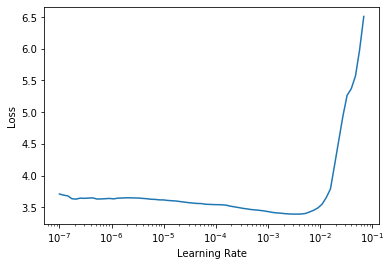

```python
learn.lr_find()
```

{% endraw %}

The learning rate finder curve suggests picking something between 1e-4 and 1e-3.

{% raw %}

```python
learn.fit_one_cycle(1, 1e-4)
```

| epoch | train_loss | valid_loss | perplexity | time |
| --- | --- | --- | --- | --- |
| 0 | 3.646031 | 3.244000 | 25.636072 | 02:44 |

{% endraw %}

Now with just one epoch of fine-tuning and not much regularization, our model did not really improve since it was already amazing. To have a look at some generated texts, let's take a prompt that looks like a wikipedia article:

{% raw %}

```python
df_valid.head(1)
```

|  | 0 |
| --- | --- |
| 0 | \n = Tropical Storm <unk> ( 2008 ) = \n \n Tropical Storm <unk> was the tenth tropical storm of the 2008 Atlantic hurricane season . <unk> developed out of a strong tropical wave which moved off the A… |

{% endraw %}

Article seems to begin with new line and the title between = signs, so we will mimic that:

{% raw %}

```python
prompt = "\n = Unicorn = \n \n A unicorn is a magical creature with a rainbow tail and a horn"
```

{% endraw %}

The prompt needs to be tokenized and numericalized, so we use the same function as before to do this, before we use the `generate` method of the model.

{% raw %}

```python
prompt_ids = tokenizer.encode(prompt)
inp = tensor(prompt_ids)[None].cuda()
inp.shape
```

```
torch.Size([1, 21])
```

{% endraw %} {% raw %}

```python
preds = learn.model.generate(inp, max_length=40, num_beams=5, temperature=1.5)
```

```
Setting `pad_token_id` to 50256 (first `eos_token_id`) to generate sequence
```

{% endraw %} {% raw %}

```python
tokenizer.decode(preds[0])
```

```
'\n = Unicorn = \n \n A unicorn is a magical creature with a rainbow tail and a horn on its head.\n\nA unicorn can fly at speeds of up to 100 miles per hour'
```

{% endraw %}